# Brief Analysis of Food Prices in Myanmar

[Myanmar Food Security Cluster](https://food-security-cluster-myanmar.github.io/)

19/07/2022

## About the data

This report makes use of food price monitoring data from [WFP](https://data.humdata.org/dataset/wfp-food-prices-for-myanmar?force_layout=desktop) and [Mercy Corps’ Market Analysis Unit (MAU)](http://themimu.info/market-analysis-unit). Data collection for WFP began in 2008 and is regularly updated. MAU data has been used to supplement this dataset and is more focused on the southeast.

Not all commodities whose prices have been collected have been analysed as there are insufficient observations for many food and non-food commodities. An important next step would be to cross-reference this data with environmental conditions, supply chain data and information on conflict and humanitarian access.

## 1. Food prices vs. inflation

Inflation in food commodities has largely outstripped the overall pace of inflation in Myanmar as a whole. In the plot below, commodities which have been sufficiently measured (more than 1,000 observations between 2020 and the present), the bars are coloured on the number of observations where prices have increased more than 1% a month – for reference, this is roughly equivalent to the official inflation rate of 12.63% (Central Statistics Organisation) for the whole of 2021.

Price increases are particularly predominant in palm oil. Tomatoes were the only commodity to have not experienced overall price increases beyond Myanmar’s inflation rate; however, as will be examined, its prices have undergone significant volatility.

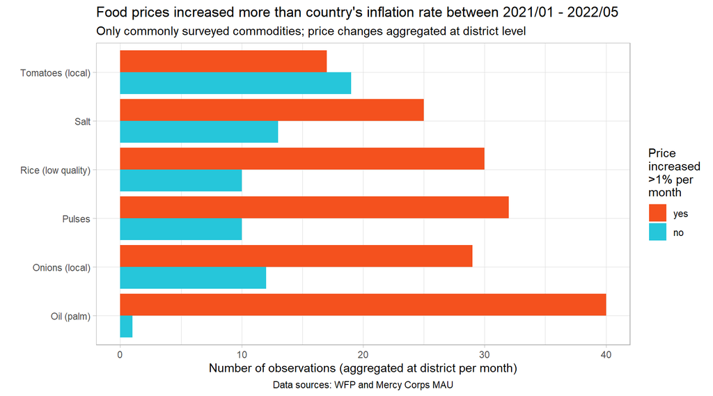

## 2. Food prices over time

The plots below show the trends in prices for monitored commodities, between 2021/01 and 2022/05. Each point is a singular observation of a single commodity in a single market.

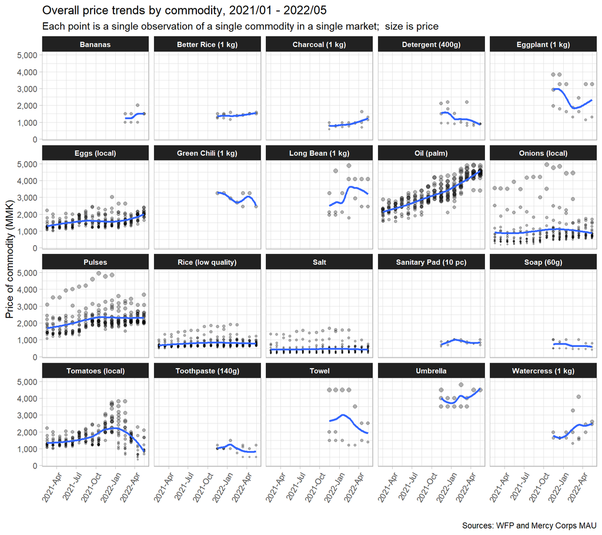

The plots below show the historical price trends of key commodities. The fluctuations in the prices of onions and tomatoes have been historically much more volatile. The last time prices saw a major drop was in the 2009 economic crisis. And following the trend, the prices of tomatoes is likely to rapidly increase. Palm oil, on the other hand, has seen a recent and very acute increase in prices.

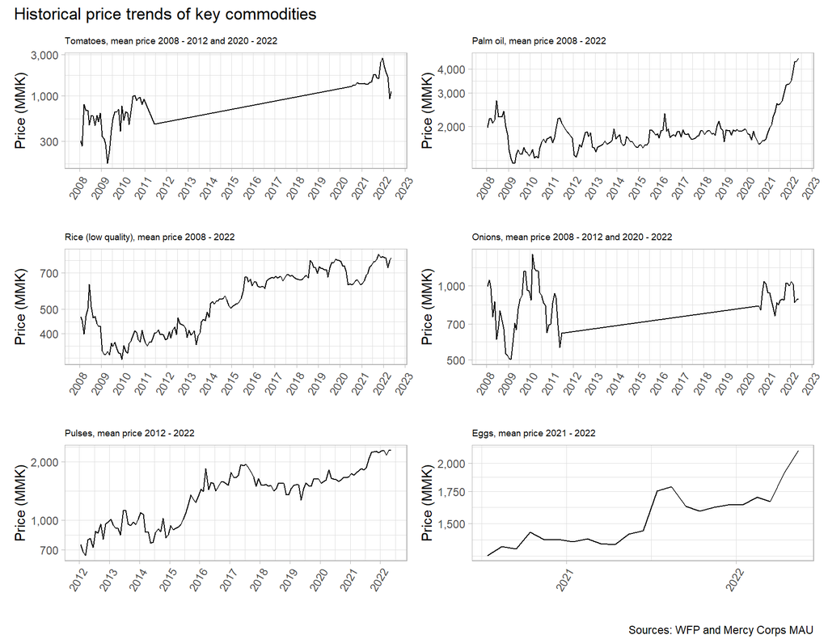

Once aggregated at state level, Shan East is visibly an area of concern, having experienced the largest or near-the-largest price increases in salt, rice, tomatoes, pulses and onions.

In Kayin, Mon and Tanintharyi, the seasonal rise and dip in prices is observed particularly clearly in the prices of onions. In Kayah and Magway, these seasonal fluctuations are still there, just much more exaggerated.

Additionally, given the trends in rice prices, it is probable that the earnings of rice producers, the largest group of farmers in Myanmar, have not been able to keep up with price increases in other key food commodities.

The plots below are faceted by state, with the date on the x-axis and prices in MMK on the y-axis. Price shocks can be observed here by looking at spikes in each of the lines.

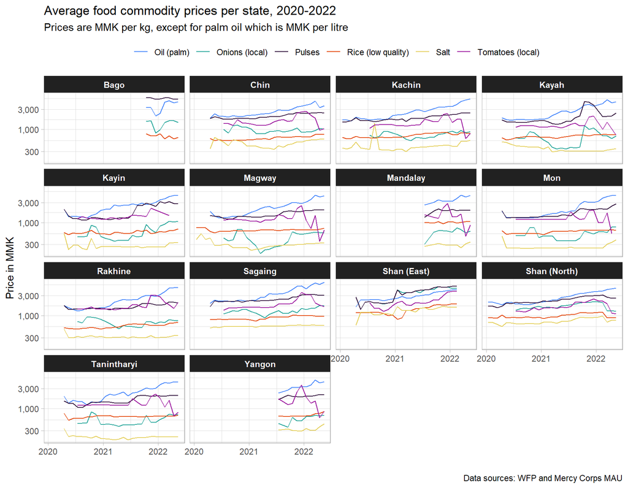

Shan (East), Sagaing and Shan (North) are all notable for their higher than average prices across all commodities, notably their price of rice. Palm oil is most expensive in Sagaing, though all areas have experienced significant price increases.

## 3. Putting Myanmar in context

Inflation has been catastrophic in Sri Lanka. The situation in Myanmar is comparatively more stable, yet is also under number stresses. Additionally, as the crisis is prolonged, the more likely the country is to suffer from global supply chain issues.

The prices of rice in Myanmar have not undergone anywhere the same amount of inflation that they have in Sri Lanka. Inflation in Myanmar has been more a constant stress rather than the pure price shock experienced in Sri Lanka. However, given the fragility of the context of Myanmar, it is not improbable that the onset of a major natural disaster or a rapid change in the conflict could deteriorate the situation further.

It is the duty of the central bank to manage inflation and stabilise markets. What is possible for aid agencies is to invest in community resilience so that vulnerable persons may better absorb the effects of and adapt to the upcoming shocks and stresses.

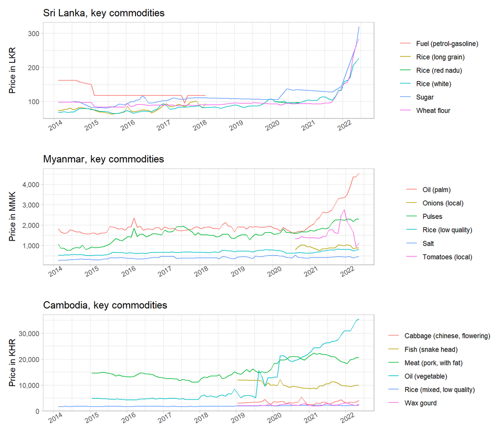

The seasonal price variations in vegetables seem much more set in their patterns and much less volatile than in Myanmar.

According to the World Bank, Myanmar’s GDP in 2022 estimated to still be around 13 percent lower than in 2019. Additionally, the security situation in Myanmar leaves a lot to be desired. According to Fitch Solutions, the Cambodian government has said it would intervene to “contain increases in the prices of basic food products”. Further [stating](https://www.phnompenhpost.com/special-reports/step-targeted-solutions-tame-runaway-inflation-economists-say), “we note higher risks of protests and public discontent with the government if economic conditions deteriorate significantly over the coming quarters.

Ultimately, the situation in Myanmar is much less politically stable than the one in Cambodia and also has much more room for deterioration. Though inflation is not yet at the level of price shocks that Sri Lanka is experiencing.

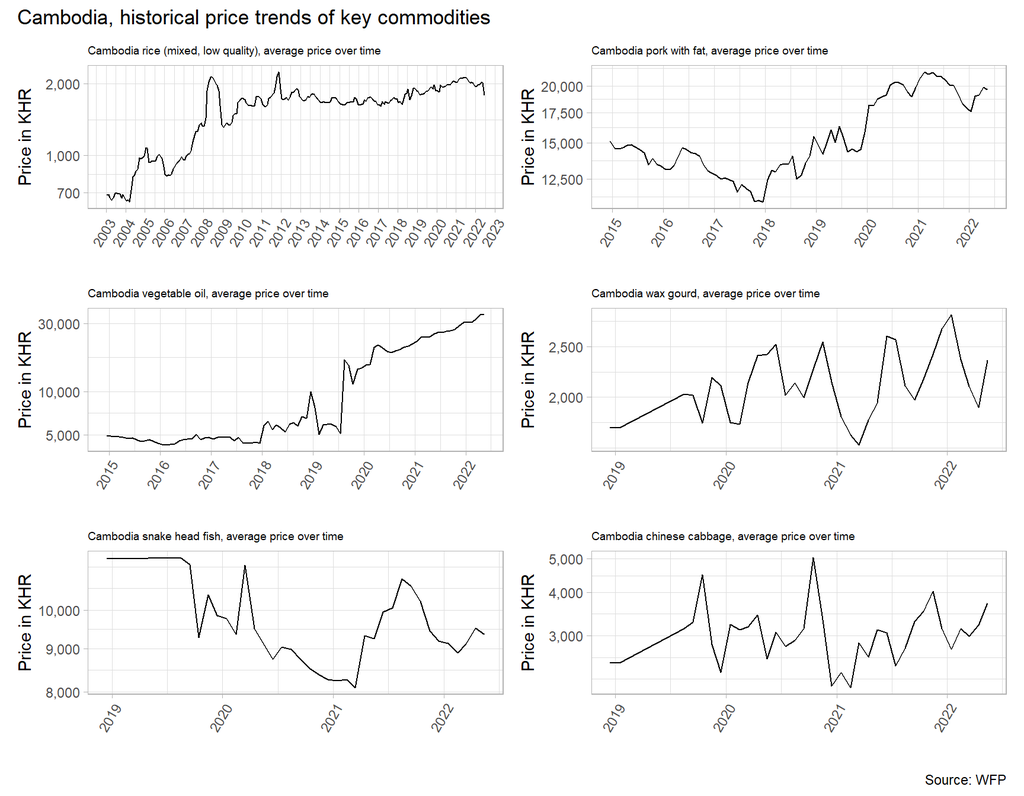

## 4. Reference maps and tables

### 4.1 Reference maps

For more information on the conflict score, please refer to the Food Security Cluster’s report [Understanding Conflict Dynamics in Myanmar](https://food-security-cluster-myanmar.github.io/exploratory-data-analysis-acled-fsc/).

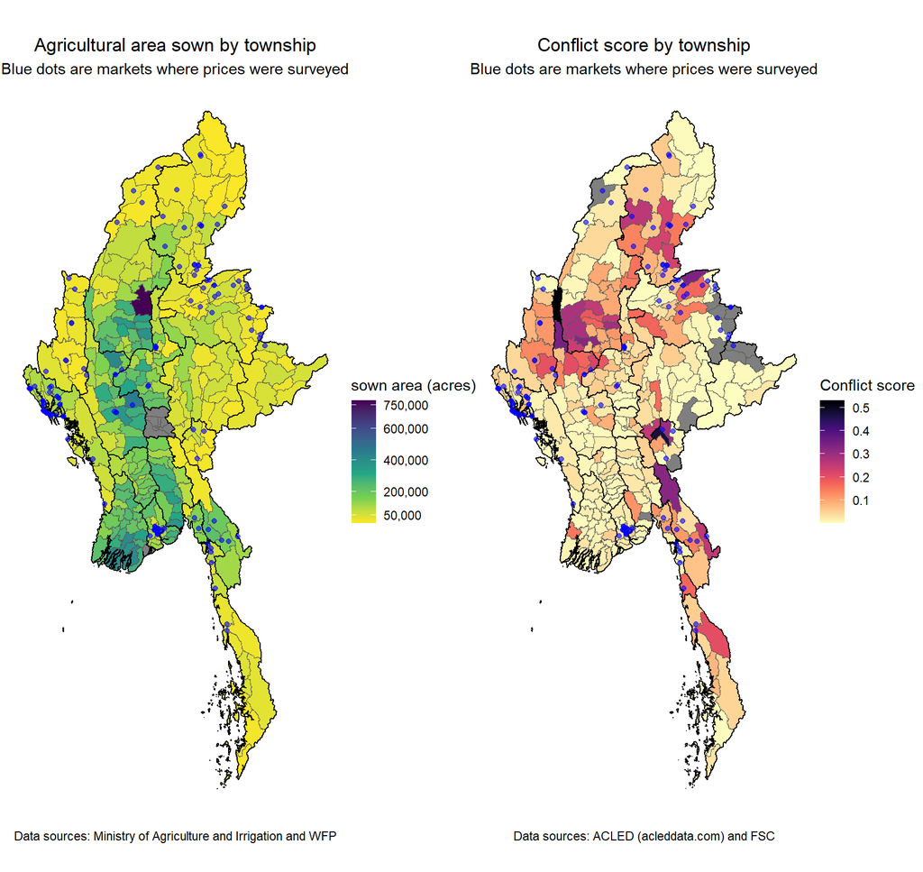

### 4.2 Interactive reference table

|  | date | commodity | admin1 | admin2 | price_MMK | %change_month |
| --- | --- | --- | --- | --- | --- | --- |
| 1 | 2021-02-15 | Eggs (local) | Chin | Falam | 1358 | -1.31 |
| 2 | 2021-02-15 | Eggs (local) | Chin | Hakha | 1250 | 0 |
| 3 | 2021-02-15 | Eggs (local) | Chin | Matupi | 1339.5 | -17.57 |
| 4 | 2021-02-15 | Eggs (local) | Chin | Mindat | 1125 | 0 |
| 5 | 2021-02-15 | Eggs (local) | Kachin | Bhamo | 1229.16666666667 | 2.43 |
| 6 | 2021-02-15 | Eggs (local) | Kachin | Mohnyin | 1162.5 | -1.06 |
| 7 | 2021-02-15 | Eggs (local) | Kachin | Myitkyina | 1362.5 | 1.76 |
| 8 | 2021-02-15 | Eggs (local) | Kayah | Loikaw | 1167 | 3 |
| 9 | 2021-02-15 | Eggs (local) | Kayin | Hpa-An | 1300 | 8.33 |
| 10 | 2021-02-15 | Eggs (local) | Magway | Magway | 1150 | 0 |

[output cut: 4119 more lines]